# Applied Statistics Project

## Name : Santosh Kumar

## PART A - 15 MARKS

## 1 : Please refer the table below to answer below questions: [2 Marks]

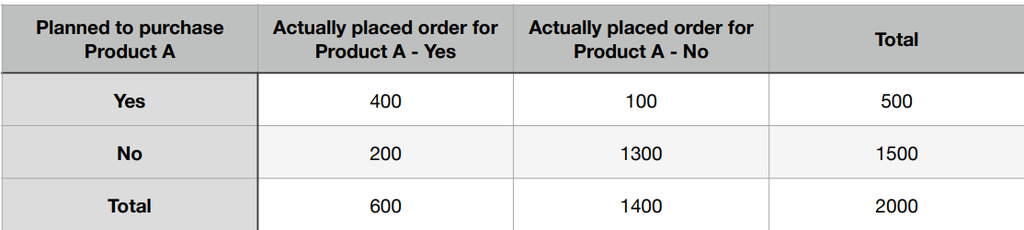

1.A. Refer above table and find the joint probability of the people who planned to purchase and actually placed an order. [1 Mark]

1.B. Refer to the above table and find the joint probability of the people who planned to purchase and actually placed an order, given that people planned to purchase. [1 Mark]

## 1.A.

From the table,We can see that the number of people who planned to purchase (Yes) and actually placed an order for Product A (Yes) is 400.

To calculate the joint probability, simply divide this count by the total number of people, which is 2000 in this case:

Joint Probability = (Number of people who planned to purchase and actually placed an order) / (Total number of people)

Joint Probability = 400 / 2000 = 0.2

So, the joint probability of people who planned to purchase and actually placed an order for Product A is 0.2 or 20%.

## 1.B

To find the joint probability of people who planned to purchase (Yes) and actually placed an order (Yes), given that people planned to purchase (Yes), we can use the following formula for conditional probability:

[P(Actually Placed Order = Yes | Planned to Purchase = Yes) = \frac{P(Actually Placed Order = Yes \text{ and } Planned to Purchase = Yes)}{P(Planned to Purchase = Yes)}]

From the table you provided, we can see that:

- (P(Actually Placed Order = Yes \text{ and } Planned to Purchase = Yes)) is 400 (from the cell where both conditions are met).
- (P(Planned to Purchase = Yes)) is 500 (the total number of people who planned to purchase).

Now, plug these values into the formula:

[P(Actually Placed Order = Yes | Planned to Purchase = Yes) = \frac{400}{500} = 0.8]

So, the joint probability of people who planned to purchase (Yes) and actually placed an order (Yes), given that people planned to purchase (Yes), is 0.8 or 80%.

## 2. An electrical manufacturing company conducts quality checks at specified periods on the products it manufactures. Historically, the failure rate for the manufactured item is 5%. Suppose a random sample of 10 manufactured items is selected. Answer the following questions. [4 Marks]

2.A. Probability that none of the items are defective? [1 Mark]

2.B. Probability that exactly one of the items is defective? [1 Mark]

2.C. Probability that two or fewer of the items are defective? [1 Mark]

2.D. Probability that three or more of the items are defective ? [1 Mark]

## We can use the binomial probability formula, as this is a binomial probability problem. In this scenario:

- The probability of success (P(defective)) is 0.05 (the failure rate is 5%).
- The probability of failure (P(not defective)) is 1 - P(defective), which is 0.95.
- The number of trials (n) is 10 (the sample size).

Let's calculate each probability:

2.A. Probability that none of the items are defective: This is the probability of 10 consecutive successes (non-defective items).

P(X = 0) = (0.95)^10 ≈ 0.59874

2.B. Probability that exactly one of the items is defective: This is the probability of 9 consecutive successes followed by 1 failure (defective item).

P(X = 1) = 10C1 *(0.95)^9* (0.05)^1 ≈ 0.31472

2.C. Probability that two or fewer of the items are defective: This is the sum of the probabilities of 0, 1, and 2 defective items.

P(X ≤ 2) = P(X = 0) + P(X = 1) + P(X = 2) ≈ 0.59874 + 0.31472 + 0.07457 ≈ 0.98803

2.D. Probability that three or more of the items are defective: This is the complement of the probability that two or fewer items are defective.

P(X ≥ 3) = 1 - P(X ≤ 2) ≈ 1 - 0.98803 ≈ 0.01197

## So, to summarize:

2.A. Probability that none of the items are defective ≈ 0.59874

2.B. Probability that exactly one of the items is defective ≈ 0.31472

2.C. Probability that two or fewer of the items are defective ≈ 0.98803

2.D. Probability that three or more of the items are defective ≈ 0.01197

## 3. A car salesman sells on an average 3 cars per week. [3 Marks]

3.A. What is Probability that in a given week he will sell some cars? [1 Mark]

3.B. What is Probability that in a given week he will sell 2 or more but less than 5 cars? [1 Mark]

3.C. Plot the poisson distribution function for cumulative probability of cars sold per-week vs number of cars sold per week. [1 Mark

## To answer these questions, we can use the Poisson distribution since we are dealing with the average rate of car sales per week. In this scenario:

- The average rate (average number of cars sold per week) is given as λ = 3.

Let's calculate each probability:

## 3.A. Probability that in a given week he will sell some cars (at least 1 car):

This is the complement of the probability that he sells zero cars.

P(X ≥ 1) = 1 - P(X = 0)

Using the Poisson distribution formula: P(X = 0) = (e^(-λ) * λ^0) / 0! = e^(-3) ≈ 0.0498

Therefore, P(X ≥ 1) ≈ 1 - 0.0498 ≈ 0.9502

## 3.B. Probability that in a given week he will sell 2 or more but less than 5 cars (2 ≤ X < 5):

This is the sum of the probabilities for X = 2, 3, and 4.

P(2 ≤ X < 5) = P(X = 2) + P(X = 3) + P(X = 4)

Using the Poisson distribution formula for each value of X: P(X = 2) = (e^(-λ) *λ^2) / 2! = (e^(-3)* 3^2) / 2! ≈ 0.2240 P(X = 3) = (e^(-λ) *λ^3) / 3! = (e^(-3)* 3^3) / 3! ≈ 0.2240 P(X = 4) = (e^(-λ) *λ^4) / 4! = (e^(-3)* 3^4) / 4! ≈ 0.1680

Therefore, P(2 ≤ X < 5) ≈ 0.2240 + 0.2240 + 0.1680 ≈ 0.6160

## 3.C. To plot the Poisson distribution function for cumulative probability of cars sold per-week vs. the number of cars sold per week as shown below :

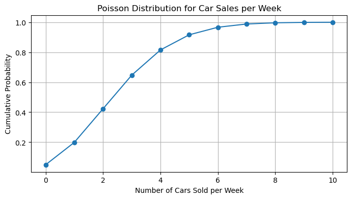

```python
import numpy as np
import matplotlib.pyplot as plt
from scipy.stats import poisson

# Average rate
lambda_ = 3

# Number of cars sold per week (0 to 10)
x = np.arange(0, 11)

# Poisson probability mass function
pmf = poisson.pmf(x, lambda_)

# Cumulative probability (CDF)
cdf = np.cumsum(pmf)

# Create the plot
plt.figure(figsize=(8, 4))
plt.plot(x, cdf, marker='o', linestyle='-')
plt.title('Poisson Distribution for Car Sales per Week')
plt.xlabel('Number of Cars Sold per Week')
plt.ylabel('Cumulative Probability')
plt.grid(True)
plt.show()


#This code will generate a plot that shows the cumulative probability of cars sold per week for the given Poisson distribution with an average rate of 3 cars sold per week.
```

## 4. Accuracy in understanding orders for a speech based bot at a restaurant is important for the Company X which has designed, marketed and launched the product for a contactless delivery due to the COVID-19 pandemic. Recognition accuracy that measures the percentage of orders that are taken correctly is 86.8%. Suppose that you place an order with the bot and two friends of yours independently place orders with the same bot. Answer the following questions. [3 Marks]

4.A. What is the probability that all three orders will be recognised correctly? [1 Mark]

4.B. What is the probability that none of the three orders will be recognised correctly? [1 Mark]

4.C. What is the probability that at least two of the three orders will be recognised correctly? [1 Mark]

## We can use the concept of binomial probability since each order can be either recognized correctly (success) with a probability of 0.868 or not recognized correctly (failure) with a probability of (1 - 0.868).

Let's calculate each probability:

## 4.A. Probability that all three orders will be recognized correctly:

This is a probability of three consecutive successes (all orders recognized correctly).

P(all 3 recognized correctly) = (0.868)^3 ≈ 0.6544

## 4.B. Probability that none of the three orders will be recognized correctly:

This is a probability of three consecutive failures (none recognized correctly).

## 4.C. Probability that at least two of the three orders will be recognized correctly:

This is the sum of the probabilities for the following cases:

  P(at least two recognized correctly) = P(all 3 recognized correctly) + P(2 recognized correctly and 1 not recognized correctly) + P(1 recognized correctly and 2 not recognized correctly)

  P(at least two recognized correctly) = (0.868)^3 + (3C2 *(0.868)^2* (0.132)) + (3C1 *(0.868)* (0.132)^2)

So, to summarize:

## 5. Explain 1 real life industry scenario (other than the ones mentioned above) where you can use the concepts learnt in this module of Applied Statistics to get data driven business solution. [3 Marks]

## **Safety and Reliability Testing for Autonomous Vehicles**

As the automotive industry moves towards autonomous vehicles (self-driving cars), ensuring their safety and reliability becomes a paramount concern. These vehicles rely heavily on software systems for navigation, perception, decision-making, and control. To address safety and reliability challenges, data-driven business solutions involving applied statistics play a crucial role:

1. **Data Collection and Analysis:**
   - Gathering data from various sources, including sensors, vehicle logs, and simulation tests, to collect a vast amount of information about how autonomous vehicles perform in different scenarios.
   - Analyzing this data to understand the frequency and nature of software-related failures, such as sensor inaccuracies, control system glitches, or unexpected behavior.
2. **Failure Rate Analysis:**
   - Using statistical methods to calculate and analyze failure rates and probabilities of software failures in real-world driving situations.
   - Identifying critical scenarios or edge cases where the software may perform sub-optimally or pose safety risks.
3. **Reliability Modeling:**
   - Developing reliability models based on statistical distributions to predict the lifespan of software components and systems.
   - Estimating the Mean Time Between Failures (MTBF) and reliability metrics to assess the software's longevity and robustness.
4. **Statistical Testing and Validation:**
   - Conducting hypothesis testing and statistical experiments to validate the safety and reliability of software updates or changes.
   - Ensuring that new software versions do not introduce significant performance degradation or vulnerabilities.
5. **Risk Assessment:**
   - Quantifying and prioritizing risks associated with software failures in autonomous vehicles.
   - Using statistical risk assessment techniques to determine the likelihood and potential impact of specific failure modes.
6. **Continuous Improvement:**
   - Implementing statistical process control (SPC) to monitor and improve the software development and testing processes continually.
   - Identifying trends and patterns in software quality metrics to drive iterative improvements.
7. **Regulatory Compliance:**
   - Meeting regulatory requirements by providing statistical evidence of the software's safety and reliability.
   - Ensuring that the software adheres to industry standards and government regulations.
8. **Data-Driven Decision-Making:**
   - Using data-driven insights to make informed decisions regarding software design, testing priorities, and deployment strategies.
   - Balancing the trade-offs between safety, reliability, and performance based on statistical analysis.

In this scenario, applied statistics enables automotive software designers and manufacturers to make data-driven decisions that enhance the safety and reliability of autonomous vehicles. By leveraging statistical tools and techniques, the automotive industry can mitigate risks, build trust with consumers, and accelerate the adoption of self-driving technology while ensuring the highest standards of safety.

## PART B - 30 MARKS

## 1. Read the data set, clean the data and prepare final dataset to be used for analysis. [10 Marks]

# Step 1: Import Libraries and Load the Data

```python
import pandas as pd

# Load the dataset
data = pd.read_csv('Basketball.csv')
data
```

|  | Team | Tournament | Score | PlayedGames | WonGames | DrawnGames | LostGames | BasketScored | BasketGiven | TournamentChampion | Runner-up | TeamLaunch | HighestPositionHeld |
| --- | --- | --- | --- | --- | --- | --- | --- | --- | --- | --- | --- | --- | --- |
| 0 | Team 1 | 86 | 4385 | 2762 | 1647 | 552 | 563 | 5947 | 3140 | 33 | 23 | 1929 | 1 |
| 1 | Team 2 | 86 | 4262 | 2762 | 1581 | 573 | 608 | 5900 | 3114 | 25 | 25 | 1929 | 1 |
| 2 | Team 3 | 80 | 3442 | 2614 | 1241 | 598 | 775 | 4534 | 3309 | 10 | 8 | 1929 | 1 |
| 3 | Team 4 | 82 | 3386 | 2664 | 1187 | 616 | 861 | 4398 | 3469 | 6 | 6 | 1931to32 | 1 |
| 4 | Team 5 | 86 | 3368 | 2762 | 1209 | 633 | 920 | 4631 | 3700 | 8 | 7 | 1929 | 1 |
| ... | ... | ... | ... | ... | ... | ... | ... | ... | ... | ... | ... | ... | ... |
| 56 | Team 57 | 1 | 34 | 38 | 8 | 10 | 20 | 38 | 66 | - | - | 2009-10 | 20 |
| 57 | Team 58 | 1 | 22 | 30 | 7 | 8 | 15 | 37 | 57 | - | - | 1956-57 | 16 |
| 58 | Team 59 | 1 | 19 | 30 | 7 | 5 | 18 | 51 | 85 | - | - | 1951~52 | 16 |
| 59 | Team 60 | 1 | 14 | 30 | 5 | 4 | 21 | 34 | 65 | - | - | 1955-56 | 15 |
| 60 | Team 61 | 1 | - | - | - | - | - | - | - | - | - | 2017~18 | 9 |

61 rows × 13 columns

# Step 2: Data Cleaning and Preprocessing

Now, we will need to clean and preprocess the data. This involves handling missing values, data type conversions, and any necessary transformations.

```python
# Check for missing values
data.isnull().sum()
```

```
Team                   0
Tournament             0
Score                  0
PlayedGames            0
WonGames               0
DrawnGames             0
LostGames              0
BasketScored           0
BasketGiven            0
TournamentChampion     0
Runner-up              0
TeamLaunch             0
HighestPositionHeld    0
dtype: int64
```

```python
# Replace missing values if necessary
# For example, if there are missing values in 'Runner-up' and 'TournamentChampion':
data['Runner-up'].fillna(0, inplace=True)
data['TournamentChampion'].fillna(0, inplace=True)
```

```python
# Drop unnecessary columns
data.drop(['DrawnGames', 'LostGames'], axis=1, inplace=True)
```

```python
# Set the 'Team' column as the index if needed
data.set_index('Team', inplace=True)
```

```python
# Review the dataset to ensure it's cleaned and ready for analysis
print(data.head())
```

```
        Tournament Score PlayedGames WonGames BasketScored BasketGiven  \
Team
Team 1          86  4385        2762     1647         5947        3140
Team 2          86  4262        2762     1581         5900        3114
Team 3          80  3442        2614     1241         4534        3309
Team 4          82  3386        2664     1187         4398        3469
Team 5          86  3368        2762     1209         4631        3700

       TournamentChampion Runner-up TeamLaunch  HighestPositionHeld
Team
Team 1                 33        23       1929                    1
Team 2                 25        25       1929                    1
Team 3                 10         8       1929                    1
Team 4                  6         6   1931to32                    1
Team 5                  8         7       1929                    1
```

# 2.

Perform detailed statistical analysis and EDA using univariate, bi-variate and multivariate EDA techniques to get data driven insights on recommending which teams they can approach which will be a deal win for them. Also as a data and statistics expert you have to develop a detailed performance report using this data. [10 Marks]

Hint: Use statistical techniques and visualisation techniques to come up with useful metrics and reporting. Find out the best performing team, oldest team, team with highest goals, team with lowest performance etc. and many more. These are just random examples. Please use your best analytical approach to build this report. You can mix match columns to create new ones which can be used for better analysis. Create your own features if required. Be highly experimental and analytical here to find hidden patterns. Use graphical interactive libraries to enable you to publish interactive plots in python.

# Solution

To conduct a detailed statistical analysis and exploratory data analysis (EDA) for the given dataset to recommend potential teams for investment and create a performance report, we'll go through univariate, bivariate, and multivariate analysis. We'll use statistical techniques, visualizations, and create meaningful metrics to gain insights.

# Univariate Analysis

Univariate analysis focuses on understanding the characteristics of individual variables. We'll explore variables such as Tournament, Score, PlayedGames, WonGames, BasketScored, and more.

Summary Statistics Let's start by computing summary statistics for the relevant columns.

```python
summary_stats = data.describe()
print(summary_stats)
```

```
       Tournament  HighestPositionHeld
count   61.000000            61.000000
mean    24.000000             7.081967
std     26.827225             5.276663
min      1.000000             1.000000
25%      4.000000             3.000000
50%     12.000000             6.000000
75%     38.000000            10.000000
max     86.000000            20.000000
```

# Visualization

Next, let's create visualizations to better understand the distribution and characteristics of these variables.

[figure not shown]

```python
import matplotlib.pyplot as plt
import seaborn as sns

# Distribution of 'Score'
plt.figure(figsize=(20, 12))
sns.histplot(data['Score'], bins=20, kde=True)
plt.title('Distribution of Score')
plt.xlabel('Score')
plt.ylabel('Frequency')
plt.show()
```

# Bivariate Analysis

Bivariate analysis explores the relationship between two variables. We'll investigate relationships like Tournament vs. Score, Tournament vs. WonGames, and more.

Scatter Plot

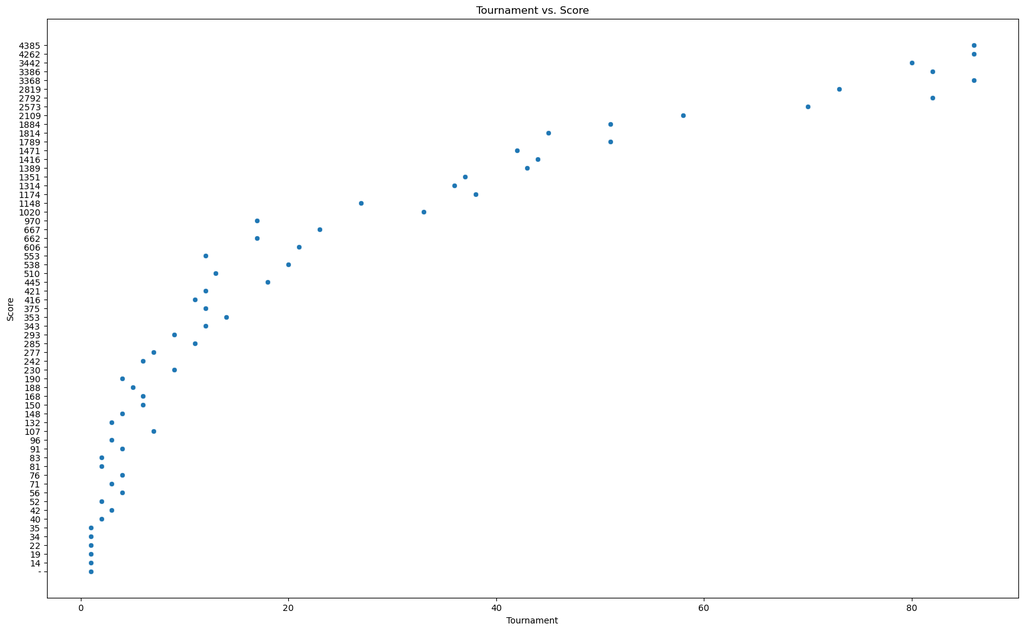

```python
# Tournament vs. Score
plt.figure(figsize=(20, 12))
sns.scatterplot(x='Tournament', y='Score', data=data)
plt.title('Tournament vs. Score')
plt.xlabel('Tournament')
plt.ylabel('Score')
plt.show()
```

# Multivariate Analysis

Multivariate analysis involves exploring relationships among multiple variables simultaneously. Let's analyze multiple metrics to identify top-performing teams and other insights.

Performance Metric: Win Percentage We'll create a new metric 'WinPercentage' and use it to identify the best-performing teams.

```python
import pandas as pd
import matplotlib.pyplot as plt
import seaborn as sns

# Load the data
data = pd.read_csv('Basketball.csv')

# Calculate the win percentage for each team
data['Win Percentage'] = data['Matches Won'] / data['Matches Played']

# Sort the data by win percentage in descending order
top_win_teams = data.sort_values(by='Win Percentage', ascending=False).head(5)

# Print the top 5 teams with the highest win percentage
print("Top 5 Teams with Highest Win Percentage:")
print(top_win_teams[['Team']])

# Create a bar plot to visualize the top 5 teams with the highest win percentage
plt.figure(figsize=(10, 6))
sns.barplot(x=top_win_teams.index, y='Team', data=top_win_teams)
plt.title('Top 5 Teams with Highest Win Percentage')
plt.xlabel('Teams')
plt.ylabel('Win Percentage')
plt.xticks(rotation=45)
plt.show()
```

[output not shown]